# Inference high and low responders 2

# Inference between high and low responders in testosterone levels

## Introduction

Haun et al. (2019) conducted their study on 30 trained men who performed a 6 weeks resistance training intervention. Two groups were formed based on training outcome measures, where the top and bottom third of the data set were assigned to a high- (*n* = 10) and low-responder group (*n* = 10), respectively. The goal of the study was to examine if HIGH responders would experience greater increases in myonuclear accretion as well as biomarkers related to ribosome biogenesis, androgen signaling, mTORc1 signaling, and mitochondrial biogenesis relative to LOW responders. Testosterone is known to induce skeletal muscle hypertrophy (Herbst and Bhasin 2004). The goal of this report is to estimate the difference in change in testosterone levels (ng/dl) between the HIGH and LOW responders from pre (T1) to post training (T3), and based on this estimate and its uncertainty, draw inference regarding the effect.

#### Null hypothesis

> There is no difference in change in testosterone levels from T1 to T3 in HIGH compared to LOW (*p* > 0.05)

#### Alternative hypothesis

> There is a significant greater increase in testosterone levels from T1 to T3 in HIGH compared to LOW

## Methods

The mean changes from T1 to T3 in HIGH and LOW were plotted as a boxplot. I used an independent two sample t-test to compare the mean changes from T1 to T3 between HIGH and LOW. The significance level was set to *p* < 0.05.

## Results

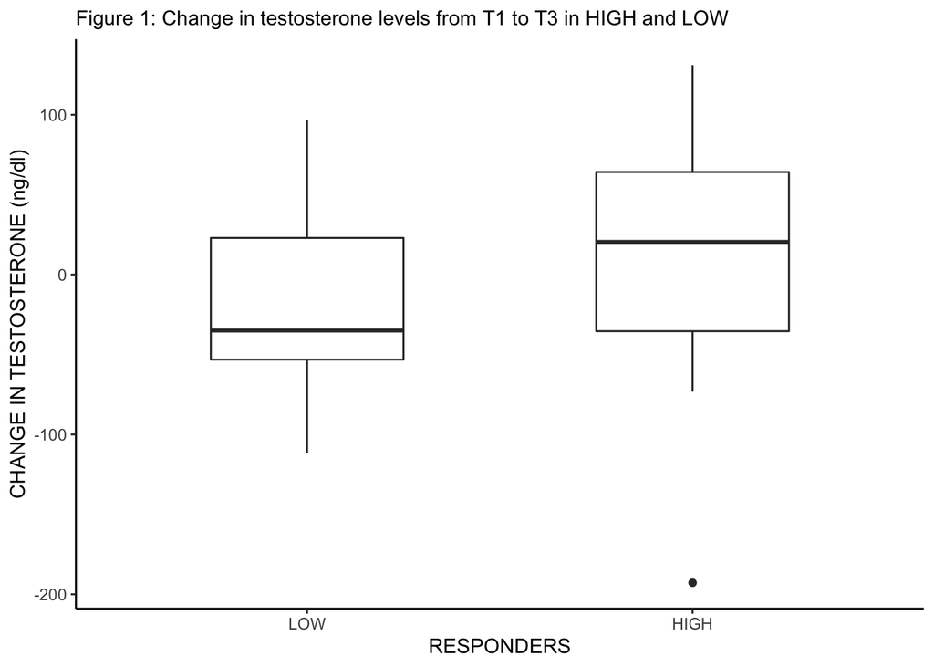

## Discussion

The findings from Haun et al. (2019) suggests that high responders do not have a greater increase in testosterone levels after a 6 weeks resistance training intervention compared to low responders.

## References

Haun, C. T., C. G. Vann, C. B. Mobley, S. C. Osburn, P. W. Mumford, P. A. Roberson, M. A. Romero, et al. 2019. “Pre-training Skeletal Muscle Fiber Size and Predominant Fiber Type Best Predict Hypertrophic Responses to 6 Weeks of Resistance Training in Previously Trained Young Men.” *Front Physiol* 10: 297.

Herbst, K. L., and S. Bhasin. 2004. “Testosterone action on skeletal muscle.” *Curr Opin Clin Nutr Metab Care* 7 (3): 271–77.